# Q4

```python
import matplotlib.pyplot as plt
import numpy as np
from mpl_toolkits.mplot3d import Axes3D
import matplotlib.pyplot as plt
import numpy as np
from matplotlib import colors
from matplotlib.ticker import PercentFormatter
```

```python
file = open("F:\AUT Courses\Fall 97 AUT\DataMining\iris.data.txt","r");
data = file.read();
x = [];
y = [];
z = [];
t = [];
# feature 1 and 2 selected
data = data.split("\n");
for d in range(0,149):
    temp = data[d].split(",");
    x.append(temp[0]);
    y.append(temp[1]);
    z.append(temp[2]);
    t.append(temp[3]);

x = np.array(x).astype(np.float)
y = np.array(y).astype(np.float)
z = np.array(z).astype(np.float)
t = np.array(t).astype(np.float)
```

# a) Histogram 2D

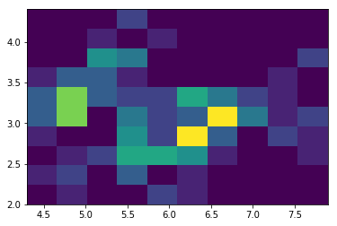

```python
plt.hist2d(x,y,bins=10)
plt.show()
```

# c) Scatter 3D

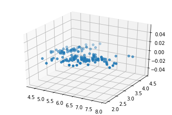

```python
fig = plt.figure();
ax = fig.add_subplot(111, projection='3d')
ax.scatter(x, y)
plt.show();
```

# b) Histogram 3D

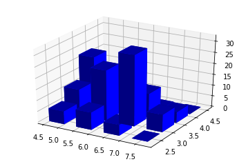

```python
fig = plt.figure()
ax = fig.add_subplot(111, projection='3d')
hist, xedges, yedges = np.histogram2d(x, y, bins=4)

xpos, ypos = np.meshgrid(xedges[:-1] + 0.25, yedges[:-1] + 0.25)
xpos = xpos.flatten('F')
ypos = ypos.flatten('F')
zpos = np.zeros_like(xpos)

dx = 0.5 * np.ones_like(zpos)
dy = dx.copy()
dz = hist.flatten()

ax.bar3d(xpos, ypos, zpos, dx, dy, dz, color='b', zsort='average')

plt.show()
```

# d) Mean and Varicane:

```python
avg_vector = [np.mean(x),np.mean(y),np.mean(z),np.mean(t)]
var_vector = [np.var(x),np.var(y),np.var(z),np.var(t)]
print(avg_vector)
print(var_vector)
```

```
[5.842953020134227, 3.0543624161073826, 3.749664429530201, 1.1946308724832215]
[0.6856718165848386, 0.18798432503040402, 3.101023377325346, 0.5799711724697085]
```

# e) Covariance Matrix

```python
np.cov(x,y)
```

```
array([[ 0.69030473, -0.03951297],
       [-0.03951297,  0.18925449]])
```

# f) Correlation Matrix

تفاوت ماتریس‌های کوواریانس و همبستگی در فایل گزارش آمده است.

```python
np.corrcoef(x,y)
```

```
array([[ 1.        , -0.10931912],
       [-0.10931912,  1.        ]])
```

# g) Virginica Features

در این بخش ابتدا ویژگی‌های مربوط به گل ویرجینیکا جدا شد و در ادامه ماتریس همبستگی بین آن ها محاسبه شد تا شبیه ترین ویژگی‌ها بدست آید.

```python
#virginica data
vir1=[];
vir2=[];
vir3=[];
vir4=[];

vir_data = data[100:150]
for d in range(0,50):
    temp = vir_data[d].split(",");
    vir1.append(temp[0]);
    vir2.append(temp[1]);
    vir3.append(temp[2]);
    vir4.append(temp[3]);

vir1 = np.array(vir1).astype(np.float)
vir2 = np.array(vir2).astype(np.float)
vir3 = np.array(vir3).astype(np.float)
vir4 = np.array(vir4).astype(np.float)


vector = [vir1,vir2,vir3,vir4]
np.corrcoef(vector)


#plt.scatter(vir1,vir3)
```

```
array([[1.        , 0.45722782, 0.86422473, 0.28110771],
       [0.45722782, 1.        , 0.40104458, 0.53772803],
       [0.86422473, 0.40104458, 1.        , 0.32210822],
       [0.28110771, 0.53772803, 0.32210822, 1.        ]])
```

# h) Best feature to predict kind of flower

در این بخش، فیچرهای مختلف برای کلاس‌های مختلف بدست آمدند تا بتوانیم از طریق نحوه توزیع ویژگی‌ها و تاثیری که بر کلاس جواب دارند، بهترین ویژگی را بیابیم تا حدس بهتری داشته باشیم.

```python
featureClass =[[0 for x in range(3)] for y in range(4)]

featureClass[0][0] = np.mean(x[1:50]) #feature 1 class 1
featureClass[0][1] = np.mean(x[50:100]) #feature 1 class 2
featureClass[0][2] = np.mean(x[100:150]) #feature 1 class 3

featureClass[1][0] = np.mean(y[1:50]) #feature 2 class 1
featureClass[1][1] = np.mean(y[50:100]) #feature 2 class 2
featureClass[1][2] = np.mean(y[100:150]) #feature 2 class 3

featureClass[2][0] = np.mean(z[1:50]) #feature 3 class 1
featureClass[2][1] = np.mean(z[50:100]) #feature 3 class 2
featureClass[2][2] = np.mean(z[100:150]) #feature 3 class 3

featureClass[3][0] = np.mean(t[1:50]) #feature 4 class 1
featureClass[3][1] = np.mean(t[50:100]) #feature 4 class 2
featureClass[3][2] = np.mean(t[100:150]) #feature 4 class 3

# print(featureClass)

print(featureClass[0][:])
print(featureClass[1][:])
print(featureClass[2][:])
print(featureClass[3][:])
```

```
[5.004081632653061, 5.936, 6.60204081632653]
[3.4163265306122454, 2.7700000000000005, 2.9734693877551024]
[1.4653061224489798, 4.26, 5.561224489795919]
[0.24489795918367344, 1.3259999999999998, 2.0306122448979593]
```

# Q5

# Linear Regression method

این کد پیاده‌سازی متد کاهش گرادیان می باشد.که به تعداد تکرار دلخواه و تتا و نرخ یادگیری اولیه شروع به تخمین تتا میکند. برای نمونه تا ۲۰۰۰۰ تکرار انجام دادیم بدلیل آنکه گرادیان بزرگ است بنابراین دیر به جواب همگرا خواهد شد بهتراست به اندازه گرادیان تقسیم شود.

```python
def gradientDescent(x, y, theta, alpha, m, numIterations):
    xTrans = x.transpose()
    for i in range(0, numIterations):
        hypothesis = np.dot(x, theta)
        loss = hypothesis - y
        cost = np.sum(loss ** 2) / (2 * m)
        print("Iteration %d | Cost: %f" % (i, cost))
        # avg gradient per example
        gradient = np.dot(xTrans, loss) / m
        # update
        theta = theta - alpha * gradient
    return theta
```

```python
datanpz = np.load("F:\AUT Courses\Fall 97 AUT\DataMining\DM_HW1\DM_HW1\data.npz");
y =datanpz['y']
x1 = datanpz['x1']
x2 = datanpz['x2']
newx = np.column_stack((x1,x2))


theta = [1,1];
alpha = 0.0001
m = 8000
numIteration = 20000
theta_opt = gradientDescent(newx,y,theta,alpha,m,numIteration)
```

```
Iteration 0 | Cost: 9809111.158097
Iteration 1 | Cost: 9583506.194005
Iteration 2 | Cost: 9364779.091482
Iteration 3 | Cost: 9152720.127189
Iteration 4 | Cost: 8947125.972893
Iteration 5 | Cost: 8747799.500456
Iteration 6 | Cost: 8554549.592775
Iteration 7 | Cost: 8367190.960491
Iteration 8 | Cost: 8185543.964279
Iteration 9 | Cost: 8009434.442562
Iteration 10 | Cost: 7838693.544479
Iteration 11 | Cost: 7673157.567944
Iteration 12 | Cost: 7512667.802644
Iteration 13 | Cost: 7357070.377823
Iteration 14 | Cost: 7206216.114711
Iteration 15 | Cost: 7059960.383451
Iteration 16 | Cost: 6918162.964388
Iteration 17 | Cost: 6780687.913585
Iteration 18 | Cost: 6647403.432450
Iteration 19 | Cost: 6518181.741326
Iteration 20 | Cost: 6392898.956944
Iteration 21 | Cost: 6271434.973608
Iteration 22 | Cost: 6153673.348007
Iteration 23 | Cost: 6039501.187538
Iteration 24 | Cost: 5928809.042031
Iteration 25 | Cost: 5821490.798783
Iteration 26 | Cost: 5717443.580783
Iteration 27 | Cost: 5616567.648052
Iteration 28 | Cost: 5518766.301978
Iteration 29 | Cost: 5423945.792583
Iteration 30 | Cost: 5332015.228604
Iteration 31 | Cost: 5242886.490325
Iteration 32 | Cost: 5156474.145063
Iteration 33 | Cost: 5072695.365232
Iteration 34 | Cost: 4991469.848906
Iteration 35 | Cost: 4912719.742805
Iteration 36 | Cost: 4836369.567624
Iteration 37 | Cost: 4762346.145650
Iteration 38 | Cost: 4690578.530573
Iteration 39 | Cost: 4620997.939446
```

[output cut: 19945 more lines]

```
Iteration 19985 | Cost: 2390970.941604
Iteration 19986 | Cost: 2390970.941604
Iteration 19987 | Cost: 2390970.941604
Iteration 19988 | Cost: 2390970.941604
Iteration 19989 | Cost: 2390970.941604
Iteration 19990 | Cost: 2390970.941604
Iteration 19991 | Cost: 2390970.941604
Iteration 19992 | Cost: 2390970.941604
Iteration 19993 | Cost: 2390970.941604
Iteration 19994 | Cost: 2390970.941604
Iteration 19995 | Cost: 2390970.941604
Iteration 19996 | Cost: 2390970.941604
Iteration 19997 | Cost: 2390970.941604
Iteration 19998 | Cost: 2390970.941604
Iteration 19999 | Cost: 2390970.941604
```

# Test Gradient

در این بخش کاهش گرادیان را بر روی داده اموزش و همچنین داده تست، امتحان میکنیم.و میزان خطا بدست آمده است.

```python
x1_test = datanpz['x1_test']
x2_test = datanpz['x2_test']
y_test = datanpz['y_test']
newxtest = np.column_stack((x1_test,x2_test))





hypothesis_train = np.dot(newx, theta_opt)
loss_train = hypothesis_train - y
cost_train = np.sum(loss_train ** 2) #Sum Square Error
print("cost result on train data:  ",cost_train);


hypothesis = np.dot(newxtest, theta_opt)
loss = hypothesis - y_test
cost = np.sum(loss ** 2) #Sum Square Error
print("cost result on test data:  ",cost);
```

```
cost result on train data:   38255535065.67179
cost result on test data:   25731535332.23358
```

# Bonus

نمودار بخش امتیازی داده های خروجی از کد برنامه در کنار داده های اصلی تست.

```
Text(0.5,0,'Y Label')
```

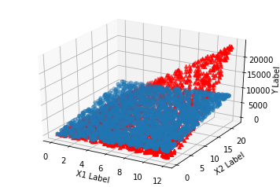

```python
fig = plt.figure()
ax = fig.add_subplot(111, projection='3d')



ax.scatter(x1_test, x2_test,hypothesis)
ax.scatter(x1_test,x2_test,y_test,marker='^',c='r')
ax.set_xlabel('X1 Label')
ax.set_ylabel('X2 Label')
ax.set_zlabel('Y Label')
```

# Stochastic Gradient Descent

در این قسمت، به صورت تصادفی یک نمونه از داده ها برای اموزش انتخاب میشود و بنابراین خطا بصورت مستقیم کاهش نمیابد.

```python
# Take only 1 instance
def stochasticgradientDescent(x, y, theta, alpha, m, numIterations):
    xTrans = x.transpose()
    for i in range(0, numIterations):
        rindex = np.random.randint(1,8000+1)
        hypothesis = np.dot(x[rindex], theta)
        loss = hypothesis - y[rindex]
        cost = np.sum(loss ** 2) / (2 * 1)
        print("Iteration %d | Cost: %f" % (i, cost))
        # avg gradient per example
        gradient = np.dot(xTrans[:,rindex], loss) / 1
        # update
        theta = theta - alpha * gradient
    return theta
```

# Test Stochastic Gradient Descent

```python
theta = [1,1];
alpha = 0.0001
m = 8000
numIteration = 20
theta_opt = stochasticgradientDescent(newx,y,theta,alpha,m,numIteration)


x1_test = datanpz['x1_test']
x2_test = datanpz['x2_test']
y_test = datanpz['y_test']
newxtest = np.column_stack((x1_test,x2_test))


hypothesis_train = np.dot(newx, theta_opt)
loss_train = hypothesis_train - y
cost_train = np.sum(loss_train ** 2) #Sum Square Error
print("cost result on train data:  ",cost_train);


hypothesis = np.dot(newxtest, theta_opt)
loss = hypothesis - y_test
cost = np.sum(loss ** 2) #Sum Square Error
print("cost result on test data:  ",cost);
```

```
Iteration 0 | Cost: 2894772.998518
Iteration 1 | Cost: 1813154.343629
Iteration 2 | Cost: 755788.056843
Iteration 3 | Cost: 75631133.514550
Iteration 4 | Cost: 18874904.226146
Iteration 5 | Cost: 615165.767443
Iteration 6 | Cost: 71441.005782
Iteration 7 | Cost: 4426320.592997
Iteration 8 | Cost: 7269264.973956
Iteration 9 | Cost: 5593.126679
Iteration 10 | Cost: 42108181.350221
Iteration 11 | Cost: 98893.736381
Iteration 12 | Cost: 677.459558
Iteration 13 | Cost: 25720910.078986
Iteration 14 | Cost: 15490.260570
Iteration 15 | Cost: 10055037.531390
Iteration 16 | Cost: 19313.216068
Iteration 17 | Cost: 1879168.613334
Iteration 18 | Cost: 128794.644826
Iteration 19 | Cost: 10697650.516447
cost result on train data:   92120904921.71655
cost result on test data:   59625868414.63132
```

# Bonus

نمودار بخش امتیازی داده های خروجی از کد برنامه در کنار داده های اصلی تست.

```
Text(0.5,0,'Y Label')
```

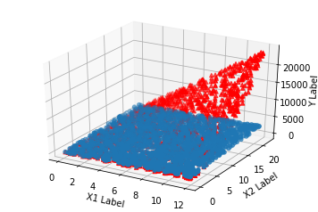

```python
fig = plt.figure()
ax = fig.add_subplot(111, projection='3d')

ax.scatter(x1_test, x2_test,hypothesis)
ax.scatter(x1_test,x2_test,y_test,marker='^',c='r')
ax.set_xlabel('X1 Label')
ax.set_ylabel('X2 Label')
ax.set_zlabel('Y Label')
```